# Analysis on Hololive VTuber's Success

### John Lee, Joshua Liu, Tianyu You

# Introduction

## VTubers and Hololive

Virtual YouTubers, or VTubers for short, are online content creators who use a virtual avatar to represent themselves. Motion-capture technology is used to make these models seem more life-like with the ability to express emotions and follow the movement of the person behind them. If you are familiar with streamers on platforms such as Twitch and Facebook, then VTubers are streamers with a virtual avatar instead of a physical character. VTubers have exploded in popularity in recent years, expanding beyond their origins in Japan to become world-wide phenomenons. It has gotten to the point where some companies are adopting a VTuber mascot. For example, N-ko is Netflix Anime's Official VTuber.

Even with VTubers debuting everyday and prominent groups being formed, there has been one VTuber agency that has stood out from its competition: Hololive. Hololive has heavily influenced the growth of Vtubers with many of its talents dominating the Vtuber scene. They currently boast 53 talents with many of them being renowned in the Vtuber community. Because of their reputation of producing popular talents, new Hololive VTubers have gained a massive following before they have even debuted. We will investigate this in more detail later. For more information about Hololive, visit their official website here: https://en.hololive.tv/.

[figure not shown]

## Defining Success

There are various ways VTubers earn money through YouTube's streaming platform. The main source is superchats, which are donations with a message from the viewers that show up on the live stream chat. Another source is memberships. Viewers are able to pay a monthly membership fee to a channel to earn special perks. For example, there may be member-only streams, emotes, and much more. Finally, there is the traditional ad revenue from videos. Since the live streams don't tend to gain a lot of views after the actual stream, this is a small portion. Check out YouTube's page for more information: https://www.youtube.com/howyoutubeworks/product-features/live/#overview.

The traditional measure of success for YouTubers is the subscribers count, and the equivalent measure for VTubers can be said to be superchat earnings. However, one interesting fact to note is that the VTuber with the highest number of subscribers does not have the highest superchat earnings. This is a bit odd because we may have expected more subscribers to translate to a higher superchat earning, and vice versa.

## Objectives

We will investigate how Hololive's reputation has affected the more recent generations. More specifically, we will compare the subscribers count and superchat earnings of the VTubers who debuted before and after the rise in popularity. To do this, we will create a predictor for the more recent VTubers, and use it on all the VTubers to simulate as if they all debuted recently. There will be several different variables we will consider when doing so. Ultimately, this will help put into context the influence of Hololive.

## Why

Hopefully, this notebook gets you interested in learning more about Hololive and VTubers in general. VTubers are a new type of content creators that are the result of advancements in technology and the world moving online during this pandemic. Technology such as face tracking, 3D modelings, and virtual and augmented reality are what makes this type of content creator possible. In the past, the technology was not yet developed enough that it could be used in this way. Also, with the world moving to an online environment, the low entry barrier and more time to consume content gave rise to VTubers. Finally, you may learn something about the data science pipeline. The notebook details everything starting from the data collection and wrangling, to analysis using linear regression and machine learning.

# Data Collection

To begin, we need to get the names, YouTube Channel ID, and generation of the Vtubers we are interested in. Each VTuber is part of a generation, which are groups within Hololive. The hololive wiki page (https://hololive.wiki/) has the desired information. Also, if you are interested in learning more about Hololive's Vtubers, the page is a great source that has detailed information about each talent.

To obtain data from the hololive wiki page, and future websites, we will use BeautifulSoup to extract the html from a website. This is called web scraping, the extraction of data from a website. To learn more about web scraping in python, check out this page: https://realpython.com/beautiful-soup-web-scraper-python/. After obtaining the html, we will use regular expression to more precisely extract the desired data.

We decided to look at the Japanese, English, and Indonesian branches of Hololive (no Holostars). This will give us a total of 54 Vtubers to look at. The data collected will be put into the `hololive` dataframe.

Get the Japanese branch name and generation.

```python
import requests
from bs4 import BeautifulSoup
import re
import pandas as pd

# information from hololive.wiki
url = "https://hololive.wiki/wiki/Main_Page"

r = requests.get(url)
soup = BeautifulSoup(r.text, "html.parser")

# web scraping
content = soup.find("div", style = "vertical-align:top; margin:4px; padding:6px 0 0 0; text-align:center; width:532px; display:inline-block")
tables = content.findAll("table")

# for regex
regex_generation = "<th.*><a href=\"\/wiki\/[\w]*\" title=\"([\w*| ]*)\">"
regex_name = "style=\"display:inline-block; overflow:hidden; border-radius:100%; border-style:solid; border:1px solid #[\w]*\"><a href=\"(\/wiki\/[\w|%|\d]*)\" title=\"([\w*| |&|#|;|+|\d|']*)\">"
holowiki = "https://hololive.wiki"

jp_branch = []
# Japanese branch
for i in range(len(tables)):
    # get generation name
    genname = re.search(regex_generation, str(tables[i])).group(1)

    gen = re.search(r'\d', genname)
    if bool(gen):
        gen = gen.group()
    else:
        gen = "Gamers"

    # returns format (wiki_link, name)
    names = re.findall(regex_name, str(tables[i]))

    for i in names:
        name = re.sub('[^a-zA-Z| ]+', '', i[1])

        jp_branch.append(["JP " + gen, name, holowiki + i[0]])
# Kiryu Coco is not in wiki because she recently graduated
jp_branch.append(["JP 4", "Kiryu Coco", "https://hololive.wiki/wiki/Kiryu_Coco"])
```

Get the English and Indonesian branches name and generation.

```python
r = requests.get(url)
soup = BeautifulSoup(r.text, "html.parser")

# web scraping
content = soup.find("div", style = "vertical-align:top; width:532px; display:inline-block")
tables = content.findAll("table")

# for regex
regex_generation = "<a href=\"\/wiki\/[\w* |\-*|_*|:*]*\" title=\"([\w| |\-*|_*|:*]*)\">"
regex_name = "style=\"display:inline-block; overflow:hidden; border-radius:100%; border-style:solid; border:1px solid #[\w]*\"><a href=\"(\/wiki\/[\w|%|\d]*)\" title=\"([\w*| |&|#|;|+|\d|']*)\">"
holowiki = "https://hololive.wiki"

en_id_branch = []
# English and Indonesian branch
for i in range(len(tables)):
    # get generation name
    genname = re.search(regex_generation, str(tables[i])).group(1)

    if "Hololive" in genname:

        if "Indonesia" not in genname:
            # English
            gen = re.search(r'Hololive English ([\w|\-|:| ]*)', genname)
            gen = gen.group(1).replace("-","").replace("Project: ","")
            branch = "EN "
        else:
            # Indonesian
            gen = re.search(r'Hololive Indonesia (\d)(st|nd|rd|th) Generation', genname).group(1)
            branch = "ID "

        # returns format (wiki_link, name)
        names = re.findall(regex_name, str(tables[i]))

        for i in names:
            name = re.sub('[^a-zA-Z| ]+', '', i[1])
            en_id_branch.append([branch + gen, name, holowiki + i[0]])

# hololive dataframe with Japanese, English, and Indonesian branch
hololive = pd.DataFrame(jp_branch + en_id_branch, columns = ["Generation", "Name", "Wiki Link"])

# Combine entries for Shirakami Fubuki (only member part of 2 generations)
hololive.at[6, "Generation"] = hololive.at[6, "Generation"] + ", " + hololive.at[15, "Generation"]
hololive = hololive.drop(index = 15)
hololive = hololive.reset_index(drop = True)
```

Get the YouTube channel id for all branches.

```python
youtubeids = []

for index in hololive.index:
    url = hololive.at[index, "Wiki Link"]

    r = requests.get(url)
    soup = BeautifulSoup(r.text, "html.parser")

    # web scraping
    content = soup.find("div", id = "mw-content-text")
    infobox = content.find("table", {"class": "infobox"})

    # for regex
    regex_youtube = "href=\"[\w*|:]*\/\/[\w]*.youtube.com*\/\w*\/([\w|-]*)"

    # channel id
    youtubeid = re.search(regex_youtube, infobox.prettify())
    youtubeids.append(youtubeid.groups()[0])
# add to hololive dataframe
hololive["Youtube ID"] = youtubeids
hololive.head()
```

|  | Generation | Name | Wiki Link | Youtube ID |
| --- | --- | --- | --- | --- |
| 0 | JP 0 | Tokino Sora | https://hololive.wiki/wiki/Tokino_Sora | UCp6993wxpyDPHUpavwDFqgg |
| 1 | JP 0 | Roboco | https://hololive.wiki/wiki/Roboco | UCDqI2jOz0weumE8s7paEk6g |
| 2 | JP 0 | Sakura Miko | https://hololive.wiki/wiki/Sakura_Miko | UC-hM6YJuNYVAmUWxeIr9FeA |
| 3 | JP 0 | Hoshimachi Suisei | https://hololive.wiki/wiki/Hoshimachi_Suisei | UC5CwaMl1eIgY8h02uZw7u8A |
| 4 | JP 0 | AZKi | https://hololive.wiki/wiki/AZKi | UC0TXe_LYZ4scaW2XMyi5_kw |

Next, we want to get data that may be of interest when looking at subscribers and superchats. From Playboard, we can get subscriber count, total views, superchat earnings, number of videos, and average live viewers (of past 15 streams). Playboard also has a chart of the most superchatted channels. Filter Country on Worldwide and Period on Total (https://playboard.co/en/youtube-ranking/most-superchatted-all-channels-in-worldwide-total). We can see that Hololive VTubers hold 8 out of the top 10 superchat earnings of all time. Narrowing the time period to this year, we find this goes up to 9 out of 10.

```python
import re

subs = []
views = []
superchats = []
videos = []
live_avgs = []
for id in hololive["Youtube ID"]:
    r = requests.get("https://playboard.co/en/channel/" + str(id))
    root = BeautifulSoup(r.content)

    # Redundancy was implemented since it may occasionally fail

    # total subs
    sub = re.findall(r"Subscribers\n\s*(\d{1,3}(,\d{3})*)", root.text)
    while len(sub) == 0:
        r = requests.get("https://playboard.co/en/channel/" + str(id))
        root = BeautifulSoup(r.content)

        sub = re.findall(r"Subscribers\n\s*(\d{1,3}(,\d{3})*)", root.text)
    subs.append(int(sub[0][0].replace(',','')))

    # total views
    view = re.findall(r"Views\n\s*(\d{1,3}(,\d{3})*)", root.text)
    while len(view) == 0:
        r = requests.get("https://playboard.co/en/channel/" + str(id))
        root = BeautifulSoup(r.content)

        view = re.findall(r"Views\n\s*(\d{1,3}(,\d{3})*)", root.text)
    views.append(int(view[0][0].replace(',','')))

    # total superchats
    superchat = re.findall(r"Super Chat\n\s*\$(\d{1,3}(,\d{3})*)", root.text)
    while len(superchat) == 0:
        r = requests.get("https://playboard.co/en/channel/" + str(id))
        root = BeautifulSoup(r.content)

        superchat = re.findall(r"Super Chat\n\s*\$(\d{1,3}(,\d{3})*)", root.text)
    superchats.append(int(superchat[0][0].replace(',','')))

    # number of videos
    video = re.findall(r"Videos\n\s*(\d{1,3}(,\d{3})*)", root.text)
    while len(video) == 0:
        r = requests.get("https://playboard.co/en/channel/" + str(id))
        root = BeautifulSoup(r.content)

        video = re.findall(r"Videos\n\s*(\d{1,3}(,\d{3})*)", root.text)
    videos.append(int(video[0][0].replace(',','')))

    # average number of live viewers
    live_avg = re.findall(r'Avg\. Viewers(\d{1,3}(,\d{3})*)', root.text)
    while len(live_avg) == 0:
        r = requests.get("https://playboard.co/en/channel/" + str(id))
        root = BeautifulSoup(r.content)

        live_avg = re.findall(r'Avg\. Viewers(\d{1,3}(,\d{3})*)', root.text)
    live_avgs.append(int(live_avg[0][0].replace(',','')))
# add to hololive dataframe
hololive["Subscribers"] = subs
hololive["Views"] = views
hololive["Superchat Earnings"] = superchats
hololive["Videos"] = videos
hololive["Average Live Views"] = live_avgs
hololive.head()
```

|  | Generation | Name | Wiki Link | Youtube ID | Subscribers | Views | Superchat Earnings | Videos | Average Live Views |
| --- | --- | --- | --- | --- | --- | --- | --- | --- | --- |
| 0 | JP 0 | Tokino Sora | https://hololive.wiki/wiki/Tokino_Sora | UCp6993wxpyDPHUpavwDFqgg | 909000 | 80623392 | 407643 | 531 | 3847 |
| 1 | JP 0 | Roboco | https://hololive.wiki/wiki/Roboco | UCDqI2jOz0weumE8s7paEk6g | 785000 | 58595018 | 368448 | 964 | 2251 |
| 2 | JP 0 | Sakura Miko | https://hololive.wiki/wiki/Sakura_Miko | UC-hM6YJuNYVAmUWxeIr9FeA | 1320000 | 158872607 | 1058884 | 999 | 15717 |
| 3 | JP 0 | Hoshimachi Suisei | https://hololive.wiki/wiki/Hoshimachi_Suisei | UC5CwaMl1eIgY8h02uZw7u8A | 1260000 | 191963972 | 667860 | 449 | 16494 |
| 4 | JP 0 | AZKi | https://hololive.wiki/wiki/AZKi | UC0TXe_LYZ4scaW2XMyi5_kw | 549000 | 24547281 | 62159 | 219 | 3958 |

We want more detailed subscriber data than just the current total. Trackholo has the subscriber data over time since their channel was created. This will give us how many subscribers a VTuber had at a certain date. All of this subscriber data will be put into the `hololive_subs` dataframe.

```python
import re
import pandas as pd

r = requests.get("https://trackholo.live/en")
root = BeautifulSoup(r.content)

# web scraping
find = root.find(lambda tag: tag.name == "script" and tag.get("type"))

hololive_subs = pd.DataFrame(columns = ["Name","Date","Days","Subs"])

chart = root.find('script', type='text/javascript').string[1976:][:-667].split("name: ")
for i in range(1,len(chart)):
    name, subs = chart[i].split("data: ")

    # name
    name = name[1:-3]

    # differences in naming between two sources
    if name == "Roboco-san":
        name = "Roboco"
    elif name == "Ouro Kuronii":
        name = "Ouro Kronii"
    elif name == "La+ Darknesss":
        name = "La Darknesss"

    # subs
    subs = subs[:-3]
    # data of the form (date, subs)
    subs_over_time = re.findall(r"x:\'(\d{4}-\d{2}-\d{2})\', y:(\d+)", subs)

    # standarized by start date
    start_date = pd.to_datetime(subs_over_time[0][0])

    for x,y in subs_over_time:
        # add row of (name, days, date, and subcribers count) to hololive_subs dataframe
        hololive_subs = hololive_subs.append({"Name":name,"Date":pd.to_datetime(x),"Days":(pd.to_datetime(x) - start_date).days,"Subs":int(y)}, ignore_index = True)
hololive_subs.head()
```

|  | Name | Date | Days | Subs |
| --- | --- | --- | --- | --- |
| 0 | Tokino Sora | 2017-12-12 | 0 | 0 |
| 1 | Tokino Sora | 2017-12-31 | 19 | 24000 |
| 2 | Tokino Sora | 2018-01-31 | 50 | 75000 |
| 3 | Tokino Sora | 2018-02-28 | 78 | 98000 |
| 4 | Tokino Sora | 2018-03-03 | 81 | 100000 |

Now that we have the subscribers over time, we want other data such as their debut date, how many days since debut, and number of subscribers after 1 week. Because of the established reputation of Hololive, new VTubers have a large number of subscribers before they even debut. So, when analyzing subscribers, we want to consider this fact, and record subscribers 1 week after debut.

Get debut date, days, and subscribers after 1 week from Trackholo.

```python
import numpy as np
import re
from datetime import date

debuts = []
subs_one_week = []
days_count = []
for index in hololive.index:
    name = hololive.at[index,"Name"]
    temp = hololive_subs[hololive_subs["Name"] == name]

    # differences in naming between two sources
    if name == "Roboco":
        name = "Roboco-san"
    elif name == "Ouro Kronii":
        name = "Ouro Kuronii"
    elif name == "La Darknesss":
        name = "La+ Darknesss"

    name = name.replace(' ','').replace('-','').replace('+','plus').lower()


    r = requests.get("https://trackholo.live/en/member/?name=" + name)
    root = BeautifulSoup(r.content)

    # debut date
    debut = pd.to_datetime(re.findall(r"Debut(\d{4}\/\d{1,2}\/\d{1,2})",root.text)[0])
    debuts.append(debut)

    # days
    today = pd.to_datetime(date.today())
    count = (today - debut).days
    days_count.append(count)

    # number of subscribers after 1 week
    for i, row in temp.iterrows():
        if (pd.to_datetime(temp.at[i,"Date"]) - debut).total_seconds() >= 7*24*3600:
            subs_one_week.append(temp.at[i,"Subs"])
            break

# add to hololive dataframe
hololive["Subscribers after 1 week"] = subs_one_week
hololive["Debut"] = debuts
hololive["Days"] = days_count
hololive
```

|  | Generation | Name | Wiki Link | Youtube ID | Subscribers | Views | Superchat Earnings | Videos | Average Live Views | Subscribers after 1 week | Debut | Days |
| --- | --- | --- | --- | --- | --- | --- | --- | --- | --- | --- | --- | --- |
| 0 | JP 0 | Tokino Sora | https://hololive.wiki/wiki/Tokino_Sora | UCp6993wxpyDPHUpavwDFqgg | 909000 | 80623392 | 407643 | 531 | 3847 | 0 | 2017-09-07 | 1564 |
| 1 | JP 0 | Roboco | https://hololive.wiki/wiki/Roboco | UCDqI2jOz0weumE8s7paEk6g | 785000 | 58595018 | 368448 | 964 | 2251 | 10200 | 2018-03-04 | 1386 |
| 2 | JP 0 | Sakura Miko | https://hololive.wiki/wiki/Sakura_Miko | UC-hM6YJuNYVAmUWxeIr9FeA | 1320000 | 158872607 | 1058884 | 999 | 15717 | 1200 | 2018-08-01 | 1236 |
| 3 | JP 0 | Hoshimachi Suisei | https://hololive.wiki/wiki/Hoshimachi_Suisei | UC5CwaMl1eIgY8h02uZw7u8A | 1260000 | 191963972 | 667860 | 449 | 16494 | 1600 | 2018-03-22 | 1368 |
| 4 | JP 0 | AZKi | https://hololive.wiki/wiki/AZKi | UC0TXe_LYZ4scaW2XMyi5_kw | 549000 | 24547281 | 62159 | 219 | 3958 | 2300 | 2018-11-15 | 1130 |
| 5 | JP 1 | Yozora Mel | https://hololive.wiki/wiki/Yozora_Mel | UCD8HOxPs4Xvsm8H0ZxXGiBw | 659000 | 20102693 | 159324 | 256 | 4509 | 5000 | 2018-05-13 | 1316 |
| 6 | JP 1, JP Gamers | Shirakami Fubuki | https://hololive.wiki/wiki/Shirakami_Fubuki | UCdn5BQ06XqgXoAxIhbqw5Rg | 1760000 | 230551919 | 740638 | 1316 | 24984 | 14800 | 2018-06-01 | 1297 |
| 7 | JP 1 | Natsuiro Matsuri | https://hololive.wiki/wiki/Natsuiro_Matsuri | UCQ0UDLQCjY0rmuxCDE38FGg | 1170000 | 98315254 | 1020590 | 645 | 4945 | 4800 | 2018-06-01 | 1297 |
| 8 | JP 1 | Aki Rosenthal | https://hololive.wiki/wiki/Aki_Rosenthal | UCFTLzh12_nrtzqBPsTCqenA | 614000 | 27230982 | 515713 | 502 | 2140 | 3000 | 2018-06-01 | 1297 |
| 9 | JP 1 | Akai Haato | https://hololive.wiki/wiki/Akai_Haato | UC1CfXB_kRs3C-zaeTG3oGyg | 1320000 | 154238587 | 640800 | 706 | 7964 | 8500 | 2018-06-02 | 1296 |
| 10 | JP 2 | Minato Aqua | https://hololive.wiki/wiki/Minato_Aqua | UC1opHUrw8rvnsadT-iGp7Cg | 1440000 | 170816302 | 1531748 | 422 | 14068 | 6000 | 2018-08-08 | 1229 |
| 11 | JP 2 | Murasaki Shion | https://hololive.wiki/wiki/Murasaki_Shion | UCXTpFs_3PqI41qX2d9tL2Rw | 947000 | 89877709 | 673532 | 284 | 19832 | 5000 | 2018-08-17 | 1220 |
| 12 | JP 2 | Nakiri Ayame | https://hololive.wiki/wiki/Nakiri_Ayame | UC7fk0CB07ly8oSl0aqKkqFg | 1190000 | 62130384 | 798210 | 194 | 28099 | 10000 | 2018-09-03 | 1203 |
| 13 | JP 2 | Yuzuki Choco | https://hololive.wiki/wiki/Yuzuki_Choco | UC1suqwovbL1kzsoaZgFZLKg | 783000 | 25791329 | 203959 | 363 | 3480 | 8000 | 2018-09-04 | 1202 |
| 14 | JP 2 | Oozora Subaru | https://hololive.wiki/wiki/Oozora_Subaru | UCvzGlP9oQwU--Y0r9id_jnA | 1210000 | 118818500 | 951865 | 505 | 21740 | 3000 | 2018-09-16 | 1190 |
| 15 | JP Gamers | Ookami Mio | https://hololive.wiki/wiki/Ookami_Mio | UCp-5t9SrOQwXMU7iIjQfARg | 906000 | 75195658 | 637201 | 409 | 13691 | 14100 | 2018-12-07 | 1108 |
| 16 | JP Gamers | Nekomata Okayu | https://hololive.wiki/wiki/Nekomata_Okayu | UCvaTdHTWBGv3MKj3KVqJVCw | 1260000 | 146614344 | 754124 | 497 | 6767 | 24500 | 2019-04-06 | 988 |
| 17 | JP Gamers | Inugami Korone | https://hololive.wiki/wiki/Inugami_Korone | UChAnqc_AY5_I3Px5dig3X1Q | 1740000 | 174768226 | 1178526 | 489 | 11022 | 21900 | 2019-04-13 | 981 |
| 18 | JP 3 | Usada Pekora | https://hololive.wiki/wiki/Usada_Pekora | UC1DCedRgGHBdm81E1llLhOQ | 1820000 | 315388793 | 2000025 | 824 | 31708 | 16100 | 2019-07-17 | 886 |
| 19 | JP 3 | Uruha Rushia | https://hololive.wiki/wiki/Uruha_Rushia | UCl_gCybOJRIgOXw6Qb4qJzQ | 1510000 | 133662235 | 3052936 | 453 | 10549 | 18500 | 2019-07-18 | 885 |
| 20 | JP 3 | Shiranui Flare | https://hololive.wiki/wiki/Shiranui_Flare | UCvInZx9h3jC2JzsIzoOebWg | 830000 | 83293989 | 1183952 | 755 | 13635 | 19700 | 2019-08-07 | 865 |
| 21 | JP 3 | Shirogane Noel | https://hololive.wiki/wiki/Shirogane_Noel | UCdyqAaZDKHXg4Ahi7VENThQ | 1380000 | 113113643 | 1016828 | 567 | 10327 | 39000 | 2019-08-08 | 864 |
| 22 | JP 3 | Houshou Marine | https://hololive.wiki/wiki/Houshou_Marine | UCCzUftO8KOVkV4wQG1vkUvg | 1750000 | 283692679 | 1732244 | 694 | 23100 | 25000 | 2019-08-11 | 861 |
| 23 | JP 4 | Amane Kanata | https://hololive.wiki/wiki/Amane_Kanata | UCZlDXzGoo7d44bwdNObFacg | 1110000 | 159235853 | 1439681 | 784 | 6920 | 85900 | 2019-12-27 | 723 |
| 24 | JP 4 | Tsunomaki Watame | https://hololive.wiki/wiki/Tsunomaki_Watame | UCqm3BQLlJfvkTsX_hvm0UmA | 1120000 | 128622931 | 1149812 | 756 | 5577 | 82100 | 2019-12-29 | 721 |
| 25 | JP 4 | Tokoyami Towa | https://hololive.wiki/wiki/Tokoyami_Towa | UC1uv2Oq6kNxgATlCiez59hw | 882000 | 75875076 | 631838 | 589 | 4385 | 55000 | 2020-01-03 | 716 |
| 26 | JP 4 | Himemori Luna | https://hololive.wiki/wiki/Himemori_Luna | UCa9Y57gfeY0Zro_noHRVrnw | 745000 | 41369189 | 495319 | 531 | 3021 | 65000 | 2020-01-04 | 715 |
| 27 | JP 5 | Yukihana Lamy | https://hololive.wiki/wiki/Yukihana_Lamy | UCFKOVgVbGmX65RxO3EtH3iw | 891000 | 84155041 | 1331216 | 535 | 8125 | 201000 | 2020-08-12 | 494 |
| 28 | JP 5 | Momosuzu Nene | https://hololive.wiki/wiki/Momosuzu_Nene | UCAWSyEs_Io8MtpY3m-zqILA | 843000 | 59188778 | 854902 | 423 | 5332 | 157000 | 2020-08-13 | 493 |
| 29 | JP 5 | Shishiro Botan | https://hololive.wiki/wiki/Shishiro_Botan | UCUKD-uaobj9jiqB-VXt71mA | 1040000 | 100218155 | 451841 | 496 | 10233 | 225000 | 2020-08-14 | 492 |
| 30 | JP 5 | Omaru Polka | https://hololive.wiki/wiki/Omaru_Polka | UCK9V2B22uJYu3N7eR_BT9QA | 885000 | 101763527 | 339993 | 556 | 3567 | 205000 | 2020-08-16 | 490 |
| 31 | JP 6 | La Darknesss | https://hololive.wiki/wiki/La%2B_Darknesss | UCENwRMx5Yh42zWpzURebzTw | 584000 | 20464035 | 116224 | 44 | 17694 | 469000 | 2021-11-26 | 23 |
| 32 | JP 6 | Takane Lui | https://hololive.wiki/wiki/Takane_Lui | UCs9_O1tRPMQTHQ-N_L6FU2g | 354000 | 15581002 | 52150 | 69 | 5541 | 292000 | 2021-11-27 | 22 |
| 33 | JP 6 | Hakui Koyori | https://hololive.wiki/wiki/Hakui_Koyori | UC6eWCld0KwmyHFbAqK3V-Rw | 416000 | 13846290 | 81111 | 42 | 7749 | 359000 | 2021-11-28 | 21 |
| 34 | JP 6 | Sakamata Chloe | https://hololive.wiki/wiki/Sakamata_Chloe | UCIBY1ollUsauvVi4hW4cumw | 645000 | 13491523 | 193006 | 30 | 7402 | 561000 | 2021-11-29 | 20 |
| 35 | JP 6 | Kazama Iroha | https://hololive.wiki/wiki/Kazama_Iroha | UC_vMYWcDjmfdpH6r4TTn1MQ | 402000 | 9513698 | 136615 | 42 | 10803 | 326000 | 2021-11-30 | 19 |
| 36 | JP 4 | Kiryu Coco | https://hololive.wiki/wiki/Kiryu_Coco | UCS9uQI-jC3DE0L4IpXyvr6w | 1440000 | 177258286 | 2921009 | 771 | 56615 | 100000 | 2019-12-28 | 722 |
| 37 | ID 1 | Ayunda Risu | https://hololive.wiki/wiki/Ayunda_Risu | UCOyYb1c43VlX9rc_lT6NKQw | 584000 | 38316448 | 53196 | 453 | 1377 | 100000 | 2020-04-10 | 618 |
| 38 | ID 1 | Moona Hoshinova | https://hololive.wiki/wiki/Moona_Hoshinova | UCP0BspO_AMEe3aQqqpo89Dg | 951000 | 47354710 | 69673 | 335 | 2949 | 99200 | 2020-04-11 | 617 |
| 39 | ID 1 | Airani Iofifteen | https://hololive.wiki/wiki/Airani_Iofifteen | UCAoy6rzhSf4ydcYjJw3WoVg | 495000 | 14523615 | 53368 | 313 | 748 | 95300 | 2020-04-12 | 616 |
| 40 | ID 2 | Kureiji Ollie | https://hololive.wiki/wiki/Kureiji_Ollie | UCYz_5n-uDuChHtLo7My1HnQ | 926000 | 38338882 | 194707 | 343 | 2328 | 252000 | 2020-12-04 | 380 |
| 41 | ID 2 | Anya Melfissa | https://hololive.wiki/wiki/Anya_Melfissa | UC727SQYUvx5pDDGQpTICNWg | 419000 | 9241028 | 53044 | 245 | 899 | 169000 | 2020-12-05 | 379 |
| 42 | ID 2 | Pavolia Reine | https://hololive.wiki/wiki/Pavolia_Reine | UChgTyjG-pdNvxxhdsXfHQ5Q | 532000 | 26198488 | 100954 | 384 | 1225 | 178000 | 2020-12-06 | 378 |
| 43 | EN Myth | Mori Calliope | https://hololive.wiki/wiki/Mori_Calliope | UCL_qhgtOy0dy1Agp8vkySQg | 1840000 | 223456074 | 1181625 | 377 | 13825 | 258000 | 2020-09-12 | 463 |
| 44 | EN Myth | Takanashi Kiara | https://hololive.wiki/wiki/Takanashi_Kiara | UCHsx4Hqa-1ORjQTh9TYDhww | 1280000 | 98484418 | 1000359 | 418 | 7208 | 198000 | 2020-09-12 | 463 |
| 45 | EN Myth | Ninomae Inanis | https://hololive.wiki/wiki/Ninomae_Ina%27nis | UCMwGHR0BTZuLsmjY_NT5Pwg | 1300000 | 79494716 | 460240 | 328 | 10577 | 239000 | 2020-09-13 | 462 |
| 46 | EN Myth | Gawr Gura | https://hololive.wiki/wiki/Gawr_Gura | UCoSrY_IQQVpmIRZ9Xf-y93g | 3670000 | 215878756 | 877466 | 274 | 24265 | 384000 | 2020-09-13 | 462 |
| 47 | EN Myth | Watson Amelia | https://hololive.wiki/wiki/Watson_Amelia | UCyl1z3jo3XHR1riLFKG5UAg | 1560000 | 106168560 | 547793 | 453 | 8996 | 246000 | 2020-09-13 | 462 |
| 48 | EN HOPE | IRyS | https://hololive.wiki/wiki/IRyS | UC8rcEBzJSleTkf_-agPM20g | 737000 | 26809111 | 161583 | 115 | 5319 | 500000 | 2021-07-11 | 161 |
| 49 | EN Council | Tsukumo Sana | https://hololive.wiki/wiki/Tsukumo_Sana | UCsUj0dszADCGbF3gNrQEuSQ | 256000 | 7740339 | 82056 | 58 | 3394 | 133000 | 2021-08-23 | 118 |
| 50 | EN Council | Ceres Fauna | https://hololive.wiki/wiki/Ceres_Fauna | UCO_aKKYxn4tvrqPjcTzZ6EQ | 399000 | 16578011 | 65496 | 75 | 6434 | 205000 | 2021-08-23 | 118 |
| 51 | EN Council | Ouro Kronii | https://hololive.wiki/wiki/Ouro_Kronii | UCmbs8T6MWqUHP1tIQvSgKrg | 584000 | 16852698 | 145925 | 59 | 9490 | 275000 | 2021-08-23 | 118 |
| 52 | EN Council | Nanashi Mumei | https://hololive.wiki/wiki/Nanashi_Mumei | UC3n5uGu18FoCy23ggWWp8tA | 486000 | 14473762 | 62446 | 69 | 9390 | 225000 | 2021-08-23 | 118 |
| 53 | EN Council | Hakos Baelz | https://hololive.wiki/wiki/Hakos_Baelz | UCgmPnx-EEeOrZSg5Tiw7ZRQ | 403000 | 17552053 | 76071 | 93 | 6894 | 203000 | 2021-08-23 | 118 |

# Analysis

## Subscribers Over Time

Let's begin by visualizing the subscribers over time.

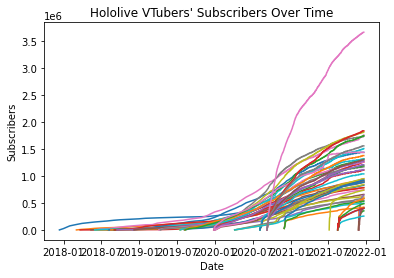

```python
import matplotlib.pyplot as plt

fig, ax = plt.subplots()

# labels
ax.set_xlabel("Date")
ax.set_ylabel("Subscribers")
ax.set_title("Hololive VTubers' Subscribers Over Time")

for i in hololive.index:
    temp = hololive_subs[hololive_subs["Name"] == hololive.at[i, "Name"]]

    # plot for each VTuber
    plt.plot(temp["Date"], temp["Subs"])
plt.show()
```

This does not look very helpful because VTubers debuted at different dates. We can standardize this by converting the dates into days since debut. It will be noted here that there is an obvious line separate from the rest. That is Gawr Gura, who has the most subscribers of any VTuber, including outside of Hololive, at around 3.5 million subscribers.

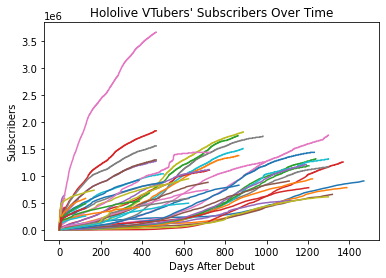

```python
fig, ax = plt.subplots()

# labels
ax.set_xlabel("Days After Debut")
ax.set_ylabel("Subscribers")
ax.set_title("Hololive VTubers' Subscribers Over Time")

for i in hololive.index:
    temp = hololive_subs[hololive_subs["Name"] == hololive.at[i, "Name"]]

    # plot for each VTuber
    plt.plot(temp["Days"], temp["Subs"])

plt.show()
```

This looks better. We can see that there are roughly 3 clusters: one from 0 to 500, another from 501 to 1100, and the final from 1101 onwards. Let's separate these "eras" to see if there is any significance.

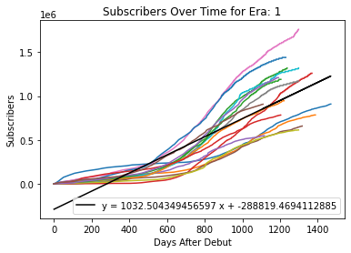

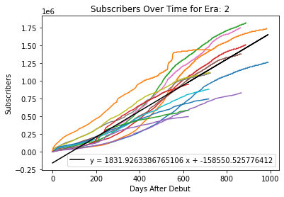

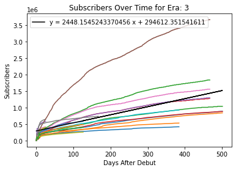

```python
from datetime import date
from sklearn.linear_model import LinearRegression
from sklearn import linear_model
import numpy as np

era = []
# today's date
today = pd.to_datetime(date.today())

for i in hololive.index:
    # calculate number of days
    days = (today - hololive.at[i, "Debut"]).days

    # assign era
    if days > 1100:
        era.append(1)
    elif days > 500:
        era.append(2)
    else:
        era.append(3)
# add to hololive dataframe
hololive["Era"] = era

# create 3 plots
axs = []
fig1, ax1 = plt.subplots()
axs.append(ax1)
fig2, ax2 = plt.subplots()
axs.append(ax2)
fig3, ax3 = plt.subplots()
axs.append(ax3)

for i in range(1,4):
    # dataframe for each era
    era = hololive[hololive["Era"] == i]
    total_days = []
    total_subs = []

    for j in era.index:
        temp = hololive_subs[hololive_subs["Name"] == era.at[j,"Name"]]

        for k in temp.index:
            total_days.append(temp.at[k,"Days"])
            total_subs.append(temp.at[k,"Subs"])
        # plot for each VTuber
        axs[i-1].plot(temp["Days"],temp["Subs"])

    # select columns
    X = np.array(total_days).reshape(-1,1)
    Y = np.array(total_subs)

    # linear regression
    regr = linear_model.LinearRegression()
    regr.fit(X, Y)

    # line of best fit in black
    y_pred = regr.predict(X)
    axs[i-1].plot(X, y_pred,'black', label = "y = "+ str(regr.coef_[0]) + " x + " + str(regr.intercept_))
    axs[i-1].legend(loc = "best")

    # labels
    axs[i-1].set_xlabel("Days After Debut")
    axs[i-1].set_ylabel("Subscribers")
    axs[i-1].set_title("Subscribers Over Time for Era: " + str(i))
```

From these graphs, we can see the influence of Hololive's reputation. The linear regression is the black line, with the coefficient representing the amount of subscribers gained in a day, and the intercept representing the amount of subscribers at debut. The more recent the era, the higher the coefficient and intercept. In fact, era 3 is the only one with a positive intercept. If a new member were to join Hololive at this time, we would expect them to have around 300,000 subscribers at debut!

## Hololive Subscriber Data

Now, we will look at the data collected in the `hololive` dataframe. Since we had distinct Eras, we can make a violin plot that shows the distribution for subscribers for each Era. Here's the documentation for violin plots if you are interested in learning more: https://seaborn.pydata.org/generated/seaborn.violinplot.html.

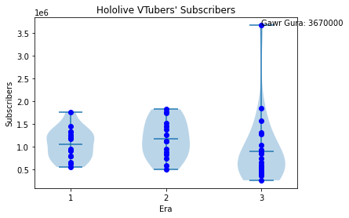

```python
fig, ax = plt.subplots()

# labels
ax.set_xlabel("Era")
ax.set_ylabel("Subscribers")
ax.set_title("Hololive VTubers' Subscribers")

subs_exp_era = []
for i in range(1,4):
    # dataframe for each era
    era = hololive[hololive["Era"] == i]
    subs_exp_era.append(era["Subscribers"])

# violin plot
ax.violinplot(subs_exp_era, [1,2,3], widths=.5, showmeans=True)
ax.set_xticks(range(4))

# scatter plot
ax.plot(hololive["Era"],hololive["Subscribers"],'bo')

# label for Gura
gura = hololive[hololive["Name"] == "Gawr Gura"]
ax.annotate("Gawr Gura: " + str(gura["Subscribers"].values[0]),(gura["Era"],gura["Subscribers"]))

plt.show()
```

In general, the Eras appear to be fairly similar. Eras 1 and 2 have roughly the same range and mean, but their distributions slightly differ. Era 3 has the lowest mean and minimum, which is to be expected since they recently debuted. However, its maximum is very high because of Gawr Gura.

## Comparing Different Eras

Remember our objective: we want to compare these different eras to see what would happen if other Eras had Hololive's established reputation. To do this, we need to first standardize our variables. Almost all of the variables naturally grow over time. This is why the Eras appear to be similar: time boosts the numbers of the older eras and Hololive's reputation boosts the numbers of the more recent eras. A simple fix is to divide each by the number of days. The standardized data will be put into the `hololive_std` dataframe. For a more in depth explanation and example of standardizing variables, look at: https://statisticsbyjim.com/regression/standardize-variables-regression/.

```python
hololive_std = pd.DataFrame(columns = ["Name","Generation","Subscribers","Views","Superchat Earnings","Videos","Average Live Views","Era"])

for i in hololive.index:
    days = float(hololive.at[i, "Days"])

    # no change
    name = hololive.at[i, "Name"]
    gen = hololive.at[i,"Generation"]
    avg_views = hololive.at[i, "Average Live Views"]
    era = hololive.at[i, "Era"]

    # standardize by days
    subs = float(hololive.at[i, "Subscribers"])/days
    views = float(hololive.at[i, "Views"])/days
    superchats = float(hololive.at[i, "Superchat Earnings"])/days
    videos = float(hololive.at[i, "Videos"])/days

    # add to hololive_std
    hololive_std = hololive_std.append({"Name":name,"Generation":gen,"Subscribers":subs,"Views":views,"Superchat Earnings":superchats,"Videos":videos,"Era":era,"Average Live Views":avg_views}, ignore_index = True)
hololive_std.head()
```

|  | Name | Generation | Subscribers | Views | Superchat Earnings | Videos | Average Live Views | Era |
| --- | --- | --- | --- | --- | --- | --- | --- | --- |
| 0 | Tokino Sora | JP 0 | 581.202046 | 51549.483376 | 260.641304 | 0.339514 | 3847 | 1 |
| 1 | Roboco | JP 0 | 566.378066 | 42276.347763 | 265.835498 | 0.695527 | 2251 | 1 |
| 2 | Sakura Miko | JP 0 | 1067.961165 | 128537.707929 | 856.702265 | 0.808252 | 15717 | 1 |
| 3 | Hoshimachi Suisei | JP 0 | 921.052632 | 140324.540936 | 488.201754 | 0.328216 | 16494 | 1 |
| 4 | AZKi | JP 0 | 485.840708 | 21723.257522 | 55.007965 | 0.193805 | 3958 | 1 |

Let's look at the standardized data.

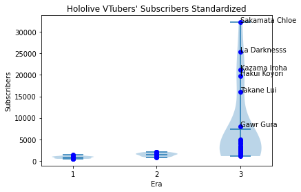

```python
fig, ax = plt.subplots()

# labels
ax.set_xlabel("Era")
ax.set_ylabel("Subscribers")
ax.set_title("Hololive VTubers' Subscribers Standardized")

subs_exp_era = []
for i in range(1,4):
    # dataframe for each era
    era = hololive_std[hololive_std["Era"] == i]
    subs_exp_era.append(era["Subscribers"])

# violin plot
ax.violinplot(subs_exp_era, [1,2,3], widths=.5, showmeans=True)
ax.set_xticks(range(4))

# scatter plot
ax.plot(hololive_std["Era"],hololive_std["Subscribers"],'bo')

# label for Gura and HoloX
gura = hololive_std[hololive_std["Name"] == "Gawr Gura"]
ax.annotate("Gawr Gura",(gura["Era"],gura["Subscribers"]))
holox = hololive_std[hololive_std["Generation"] == "JP 6"]
for i in holox.index:
    ax.annotate(holox.at[i,"Name"],(holox.at[i,"Era"],holox.at[i,"Subscribers"]))

plt.show()
```

Now we can clearly see the effect of Hololive's reputation. Eras 1 and 2 appear to be similar, with both of them being vastly different from Era 3. HoloX, the most recent generation, consists of Sakamata Chloe, Laplus Darkness, Kazama Iroha, Hakui Koyori, and Takane Lui. They all have very high numbers, right skewing Era 3. However, excluding HoloX, we can still see that Era 3 has the highest growth with Gawr Gura leading the way.

To simulate Era 3 for all Hololive members, we can make a predictor for Subscribers using Era 3, and apply it to Era 1 and 2. We will use sklearn's linear regression model to create a predictor. The documentation can be found here: https://scikit-learn.org/stable/modules/generated/sklearn.linear_model.LinearRegression.html. It can be shown that there does indeed appear to be a linear correlation between the variables. For more about the assumptions and why we use linear models, check out this resource: https://www.ibm.com/topics/linear-regression.

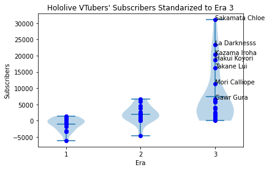

```python
import pandas
from sklearn import linear_model

temp = hololive_std[hololive_std["Era"] == 3]

# input features
X = temp[["Views","Superchat Earnings","Videos","Average Live Views"]]
# to predict
Y = temp["Subscribers"]

# linear regression
regr = linear_model.LinearRegression()
regr.fit(X, Y)

# predictor
y_pred = regr.predict(X)
y_pred

fig, ax = plt.subplots()

# labels
ax.set_xlabel("Era")
ax.set_ylabel("Subscribers")
ax.set_title("Hololive VTubers' Subscribers Standarized to Era 3")

subs_exp_era = []
for i in range(1,4):
    # dataframe for each era
    era = hololive_std[hololive_std["Era"] == i]

    X = era[["Views","Superchat Earnings","Videos","Average Live Views"]]
    y_pred = regr.predict(X)

    subs_exp_era.append(y_pred)

# violin plot
ax.violinplot(subs_exp_era, [1,2,3], widths=.5, showmeans=True)
ax.set_xticks(range(4))

# scatter plot
ax.plot(hololive_std["Era"],regr.predict(hololive_std[["Views","Superchat Earnings","Videos","Average Live Views"]]),'bo')

# label for members of interest
gura = hololive_std[hololive_std["Name"] == "Gawr Gura"]
ax.annotate("Gawr Gura",(gura["Era"],regr.predict(gura[["Views","Superchat Earnings","Videos","Average Live Views"]])))
calli = hololive_std[hololive_std["Name"] == "Mori Calliope"]
ax.annotate("Mori Calliope",(calli["Era"],regr.predict(calli[["Views","Superchat Earnings","Videos","Average Live Views"]])))
holox = hololive_std[hololive_std["Generation"] == "JP 6"]
for i in holox.index:
    member = hololive_std[hololive_std["Name"] == holox.at[i,"Name"]]
    ax.annotate(holox.at[i,"Name"],(holox.at[i,"Era"],regr.predict(member[["Views","Superchat Earnings","Videos","Average Live Views"]])))

plt.show()
```

We get different results from before. None of the Eras appear to be very similar, but there is still an increase across Eras. Era 1 is skewed left, Era 2 is normal, and Era 3 is skewed right. Once again, HoloX has very high numbers. In this case, this is likely because there has not been enough time for things to settle. This begs the question: how long will HoloX remain at the top? Excluding Holo X, we can see that Era 2 and Era 3 are fairly similar with Mori Calliope leading the way.

## Hololive Superchat Data

Let's look at superchat earnings now.

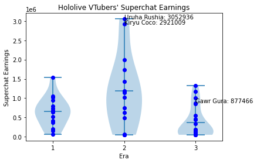

```python
fig, ax = plt.subplots()

# labels
ax.set_xlabel("Era")
ax.set_ylabel("Superchat Earnings")
ax.set_title("Hololive VTubers' Superchat Earnings")

subs_exp_era = []
for i in range(1,4):
    # dataframe for each era
    era = hololive[hololive["Era"] == i]
    subs_exp_era.append(era["Superchat Earnings"])

# violin plot
ax.violinplot(subs_exp_era, [1,2,3], widths=.5, showmeans=True)
ax.set_xticks(range(4))

# scatter plot
ax.plot(hololive["Era"],hololive["Superchat Earnings"],'bo')

# label for members of interest
gura = hololive[hololive["Name"] == "Gawr Gura"]
ax.annotate("Gawr Gura: " + str(gura["Superchat Earnings"].values[0]),(gura["Era"],gura["Superchat Earnings"]))
rushia = hololive[hololive["Name"] == "Uruha Rushia"]
ax.annotate("Uruha Rushia: " + str(rushia["Superchat Earnings"].values[0]),(rushia["Era"],rushia["Superchat Earnings"]))
coco = hololive[hololive["Name"] == "Kiryu Coco"]
ax.annotate("Kiryu Coco: " + str(coco["Superchat Earnings"].values[0]),(coco["Era"],coco["Superchat Earnings"]))


plt.show()
```

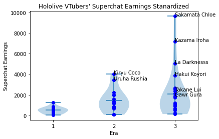

```python
fig, ax = plt.subplots()

# labels
ax.set_xlabel("Era")
ax.set_ylabel("Superchat Earnings")
ax.set_title("Hololive VTubers' Superchat Earnings Standardized")

subs_exp_era = []
for i in range(1,4):
    # dataframe for each era
    era = hololive_std[hololive_std["Era"] == i]
    subs_exp_era.append(era["Superchat Earnings"])

# violin plot
ax.violinplot(subs_exp_era, [1,2,3], widths=.5, showmeans=True)
ax.set_xticks(range(4))

# scatter plot
ax.plot(hololive_std["Era"],hololive_std["Superchat Earnings"],'bo')

# label for members of interest
gura = hololive_std[hololive_std["Name"] == "Gawr Gura"]
ax.annotate("Gawr Gura",(gura["Era"],gura["Superchat Earnings"]))
rushia = hololive_std[hololive_std["Name"] == "Uruha Rushia"]
ax.annotate("Uruha Rushia",(rushia["Era"],rushia["Superchat Earnings"]))
coco = hololive_std[hololive_std["Name"] == "Kiryu Coco"]
ax.annotate("Kiryu Coco",(coco["Era"],coco["Superchat Earnings"]))
holox = hololive_std[hololive_std["Generation"] == "JP 6"]
for i in holox.index:
    ax.annotate(holox.at[i,"Name"],(holox.at[i,"Era"],holox.at[i,"Superchat Earnings"]))


plt.show()
```

We get different results if standardized. Now Era 3 has the highest superchat earnings, with HoloX at the top. Much like the reasoning for subscribers, there likely has not been enough time for things to settle yet. Excluding HoloX, we get similar results from the non-standardized, and Era 2 is at the top again.

To simulate Era 3 for all Hololive members, we can make a predictor for Superchat Earnings using Era 3, and apply it to Era 1 and 2.

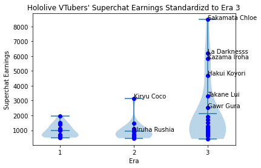

```python
import pandas
from sklearn import linear_model

temp = hololive_std[hololive_std["Era"] == 3]

# input features
X = temp[["Views","Subscribers","Videos","Average Live Views"]]
# to predict
Y = temp["Superchat Earnings"]

# linear regression
regr = linear_model.LinearRegression()
regr.fit(X, Y)

# predictor
y_pred = regr.predict(X)
y_pred

fig, ax = plt.subplots()

# labels
ax.set_xlabel("Era")
ax.set_ylabel("Superchat Earnings")
ax.set_title("Hololive VTubers' Superchat Earnings Standardizd to Era 3")

subs_exp_era = []
for i in range(1,4):
    # dataframe for each era
    era = hololive_std[hololive_std["Era"] == i]

    X = era[["Views","Subscribers","Videos","Average Live Views"]]
    y_pred = regr.predict(X)

    subs_exp_era.append(y_pred)

# violin plot
ax.violinplot(subs_exp_era, [1,2,3], widths=.5, showmeans=True)
ax.set_xticks(range(4))

# scatter plot
ax.plot(hololive_std["Era"],regr.predict(hololive_std[["Views","Subscribers","Videos","Average Live Views"]]),'bo')

# label for members of interest
gura = hololive_std[hololive_std["Name"] == "Gawr Gura"]
ax.annotate("Gawr Gura",(gura["Era"],regr.predict(gura[["Views","Subscribers","Videos","Average Live Views"]])))
rushia = hololive_std[hololive_std["Name"] == "Uruha Rushia"]
ax.annotate("Uruha Rushia",(rushia["Era"],regr.predict(rushia[["Views","Subscribers","Videos","Average Live Views"]])))
coco = hololive_std[hololive_std["Name"] == "Kiryu Coco"]
ax.annotate("Kiryu Coco",(coco["Era"],regr.predict(coco[["Views","Subscribers","Videos","Average Live Views"]])))
holox = hololive_std[hololive_std["Generation"] == "JP 6"]
for i in holox.index:
    member = holox[holox["Name"] == holox.at[i,"Name"]]
    ax.annotate(holox.at[i,"Name"],(holox.at[i,"Era"],regr.predict(member[["Views","Subscribers","Videos","Average Live Views"]])))

plt.show()
```

At a first glance, the results are similar to that of the standardized data. But at a closer look, the average of Eras 1 and 2 are lower than that of Era 3. Also, Kiriyu Coco separates herself from the rest of Era 2. This is notable, because she was one of the most influential members. During her graduation (retirement) stream, she made an estimated $160,000 with 500,000 concurrent live viewers! HoloX remains at the top. Excluding HoloX, Era 3 should have the highest average, and all the Eras appear to be more similar.

# Conclusion

Our objective was to analyze how Hololive's reputation has impacted success in subscribers and superchats. We did this by separating Hololive VTubers into 3 Eras and standardizing the variables by days. Then, we created predictors for the most recent Era, and projected it onto all the Eras. We plotted the different Eras using violin plots in which we could visualize the distribution for each Era.

We found that the HoloX generation is at the top for subscribers and superchats. This is the result of Hololive's established reputation along with recency bias. Excluding HoloX, for subscribers we see that the most recent Eras are higher, but for superchats the Eras are fairly similar. So there is a huge initial impact that boosts subscribers and superchat earnings. However, over time, the more recent generations will still grow faster, but the superchats will eventually even out.

In the future, we can continue this research by looking at more variables such as membership data and type of content they make. There are a lot of variables that can be investigated, and even superchats could possibly be broken down by videos. Also, when a new generation comes out again, we can see what has happened to the HoloX members, and see how the new members compare.